# Exploratory Data Analysis on auto-mpg dataset

## Import Libraries

```python
import pandas as pd
import numpy as np
import matplotlib as mpl
import matplotlib.pyplot as plt
%matplotlib inline
import seaborn as sns
import scipy.stats as st
from sklearn import ensemble, tree, linear_model
import missingno as msno
```

Read the auto-mpg,csv file

Note:

- 6 rows where horsepower was '?' have been removed
- Origin numerical values 1, 2, 3 have been converted to America, Europe and Asia respectively

```python
mpg = pd.read_csv("auto-mpg.csv")
```

Describe the dataset

```python
mpg.describe()
```

|  | mpg | cylinders | displacement | horsepower | weight | acceleration | model year |
| --- | --- | --- | --- | --- | --- | --- | --- |
| count | 392.000000 | 392.000000 | 392.000000 | 392.000000 | 392.000000 | 392.000000 | 392.000000 |
| mean | 23.445918 | 5.471939 | 194.411990 | 104.469388 | 2977.584184 | 15.541327 | 75.979592 |
| std | 7.805007 | 1.705783 | 104.644004 | 38.491160 | 849.402560 | 2.758864 | 3.683737 |
| min | 9.000000 | 3.000000 | 68.000000 | 46.000000 | 1613.000000 | 8.000000 | 70.000000 |
| 25% | 17.000000 | 4.000000 | 105.000000 | 75.000000 | 2225.250000 | 13.775000 | 73.000000 |
| 50% | 22.750000 | 4.000000 | 151.000000 | 93.500000 | 2803.500000 | 15.500000 | 76.000000 |
| 75% | 29.000000 | 8.000000 | 275.750000 | 126.000000 | 3614.750000 | 17.025000 | 79.000000 |
| max | 46.600000 | 8.000000 | 455.000000 | 230.000000 | 5140.000000 | 24.800000 | 82.000000 |

```python
mpg.head()
```

|  | mpg | cylinders | displacement | horsepower | weight | acceleration | model year | origin | car name |
| --- | --- | --- | --- | --- | --- | --- | --- | --- | --- |
| 0 | 18.0 | 8 | 307.0 | 130 | 3504 | 12.0 | 70 | America | chevrolet chevelle malibu |
| 1 | 15.0 | 8 | 350.0 | 165 | 3693 | 11.5 | 70 | America | buick skylark 320 |
| 2 | 18.0 | 8 | 318.0 | 150 | 3436 | 11.0 | 70 | America | plymouth satellite |
| 3 | 16.0 | 8 | 304.0 | 150 | 3433 | 12.0 | 70 | America | amc rebel sst |
| 4 | 17.0 | 8 | 302.0 | 140 | 3449 | 10.5 | 70 | America | ford torino |

```python
mpg.tail()
```

|  | mpg | cylinders | displacement | horsepower | weight | acceleration | model year | origin | car name |
| --- | --- | --- | --- | --- | --- | --- | --- | --- | --- |
| 387 | 27.0 | 4 | 140.0 | 86 | 2790 | 15.6 | 82 | America | ford mustang gl |
| 388 | 44.0 | 4 | 97.0 | 52 | 2130 | 24.6 | 82 | Europe | vw pickup |
| 389 | 32.0 | 4 | 135.0 | 84 | 2295 | 11.6 | 82 | America | dodge rampage |
| 390 | 28.0 | 4 | 120.0 | 79 | 2625 | 18.6 | 82 | America | ford ranger |
| 391 | 31.0 | 4 | 119.0 | 82 | 2720 | 19.4 | 82 | America | chevy s-10 |

```python
mpg.shape
```

```
(392, 9)
```

Examine numerical features in the dataset

```python
numeric_features = mpg.select_dtypes(include=[np.number])

numeric_features.columns
```

```
Index(['mpg', 'cylinders', 'displacement', 'horsepower', 'weight',
       'acceleration', 'model year'],
      dtype='object')
```

Examine categorical features in the dataset

```python
categorical_features = mpg.select_dtypes(include=[object])
categorical_features.columns
```

```
Index(['origin', 'car name'], dtype='object')
```

Estimate Skewness and Kurtosis

```python
mpg.skew()
```

```
mpg             0.457092
cylinders       0.508109
displacement    0.701669
horsepower      1.087326
weight          0.519586
acceleration    0.291587
model year      0.019688
dtype: float64
```

```python
mpg.kurt()
```

```
mpg            -0.515993
cylinders      -1.398199
displacement   -0.778317
horsepower      0.696947
weight         -0.809259
acceleration    0.444234
model year     -1.167446
dtype: float64
```

Plot the distribution of MPG as it plus, pand transformed with Johnson SU and logarithmic.

[output not shown]

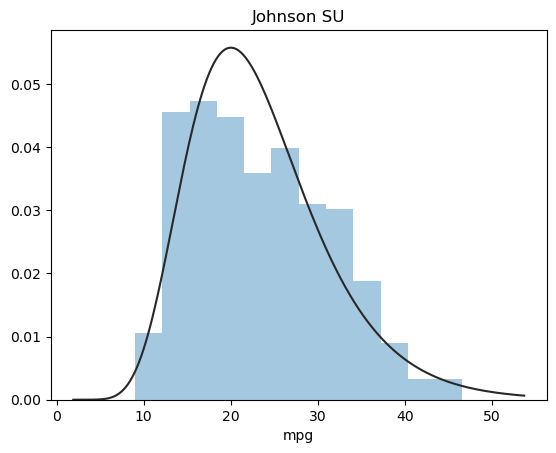

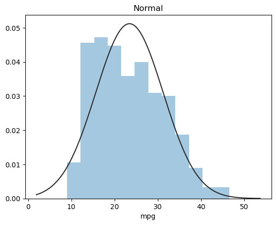

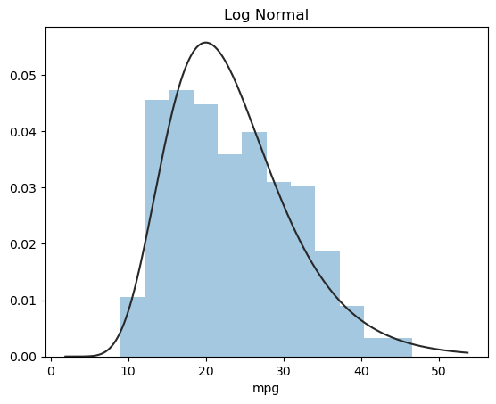

```python
y = mpg['mpg']
plt.figure(1); plt.title('Johnson SU')
sns.distplot(y, kde=False, fit=st.johnsonsu)
plt.figure(2); plt.title('Normal')
sns.distplot(y, kde=False, fit=st.norm)
plt.figure(3); plt.title('Log Normal')
sns.distplot(y, kde=False, fit=st.lognorm)
```

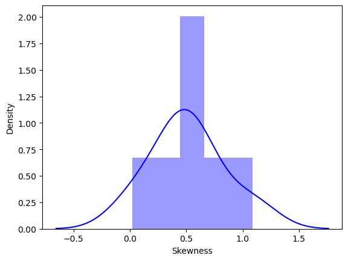

```python
sns.distplot(mpg.skew(),color='blue',axlabel ='Skewness')
```

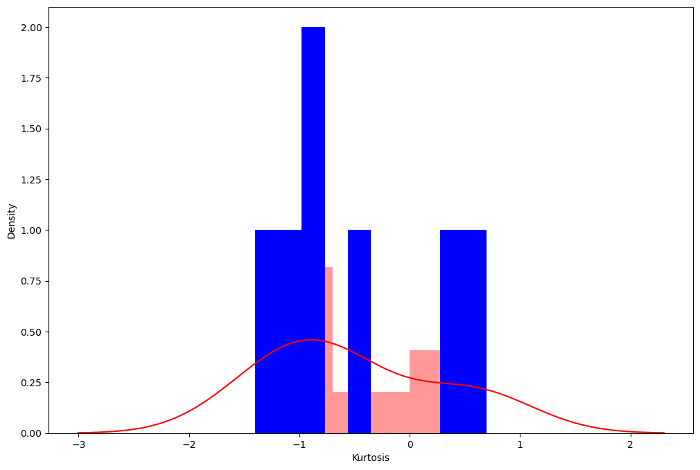

```python
plt.figure(figsize = (12,8))
sns.distplot(mpg.kurt(),color='r',axlabel ='Kurtosis',norm_hist= False, kde = True,rug = False)
plt.hist(mpg.kurt(),orientation = 'vertical',histtype = 'bar',label ='Kurtosis', color ='blue')
plt.show()
```

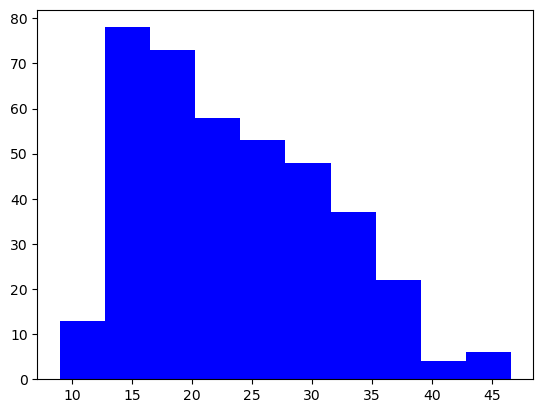

```python
plt.hist(mpg['mpg'],orientation = 'vertical',histtype = 'bar', color ='blue')
plt.show()
```

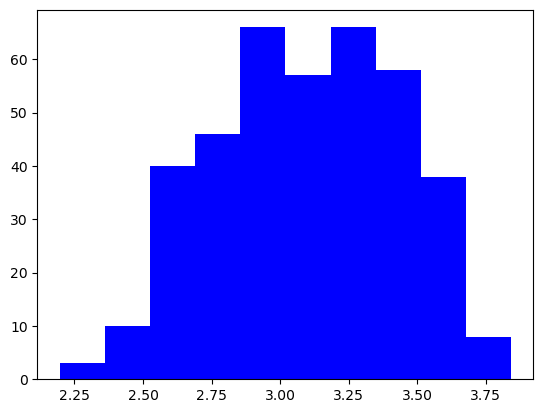

```python
target = np.log(mpg['mpg'])
target.skew()
plt.hist(target,color='blue')
```

Find Correlation coefficients between numeric features and MPG

```python
correlation = numeric_features.corr()
print(correlation['mpg'].sort_values(ascending = False),'\n')
```

```
mpg             1.000000
model year      0.580541
acceleration    0.423329
cylinders      -0.777618
horsepower     -0.778427
displacement   -0.805127
weight         -0.832244
Name: mpg, dtype: float64
```

To explore further we will start with the following visualisation methods to analyze the data better:

- Correlation Heat Map
- Zoomed Heat Map
- Pair Plot
- Scatter Plot

### Correlation Heat Map

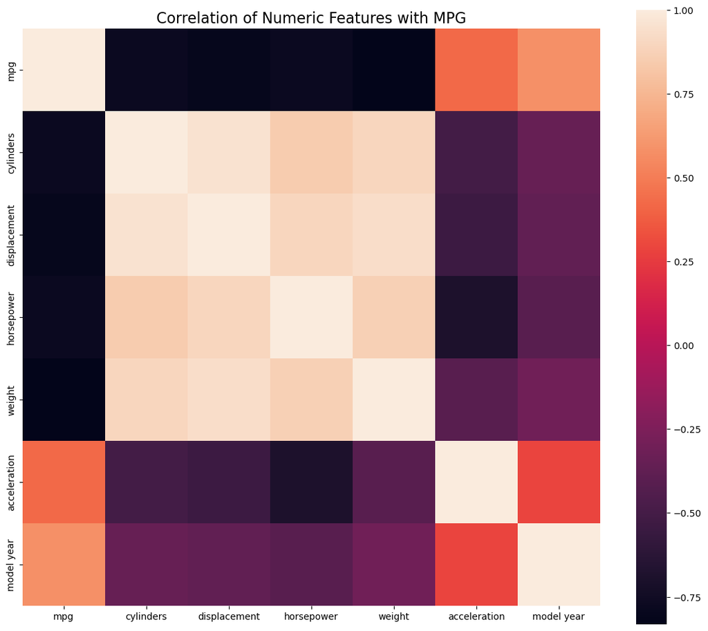

```python
f , ax = plt.subplots(figsize = (14,12))
plt.title('Correlation of Numeric Features with MPG',y=1,size=16)
sns.heatmap(correlation,square = True)
```

Cylinders, displacement, horsepower and weight are all positively correlated with each other, and negatively correlated with MPG.

### Zoomed HeatMap

#### MPG Correlation matrix

```
Index(['mpg', 'model year', 'acceleration', 'cylinders', 'horsepower',
       'displacement', 'weight'],
      dtype='object')
```

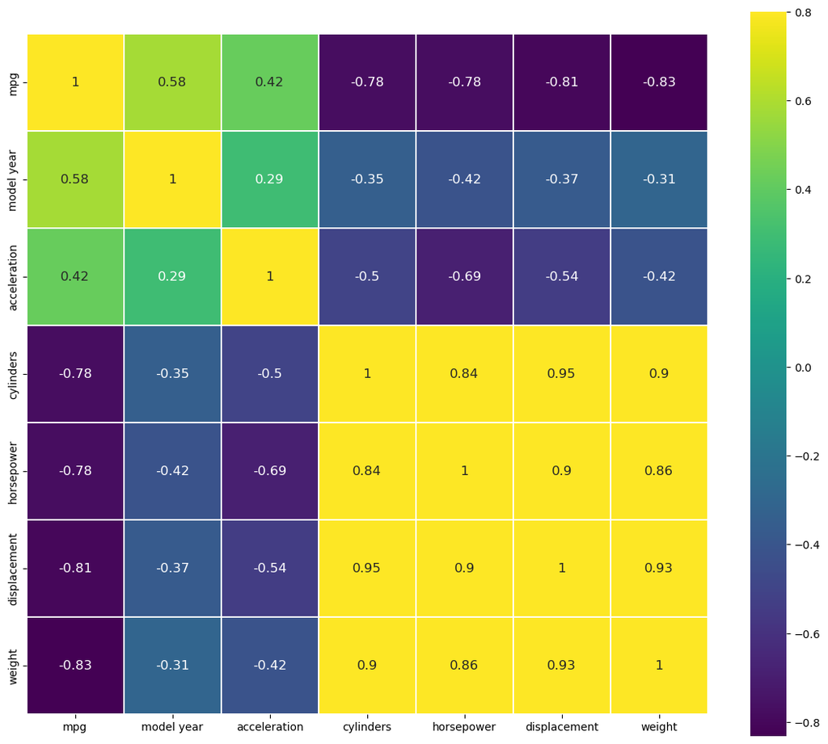

```python
k= 11
cols = correlation.nlargest(k,'mpg')['mpg'].index
print(cols)
cm = np.corrcoef(mpg[cols].values.T)
f , ax = plt.subplots(figsize = (14,12))
sns.heatmap(cm, vmax=.8, linewidths=0.01,square=True,annot=True,cmap='viridis',
            linecolor="white",xticklabels = cols.values ,annot_kws = {'size':12},yticklabels = cols.values)
```

### Pair Plot

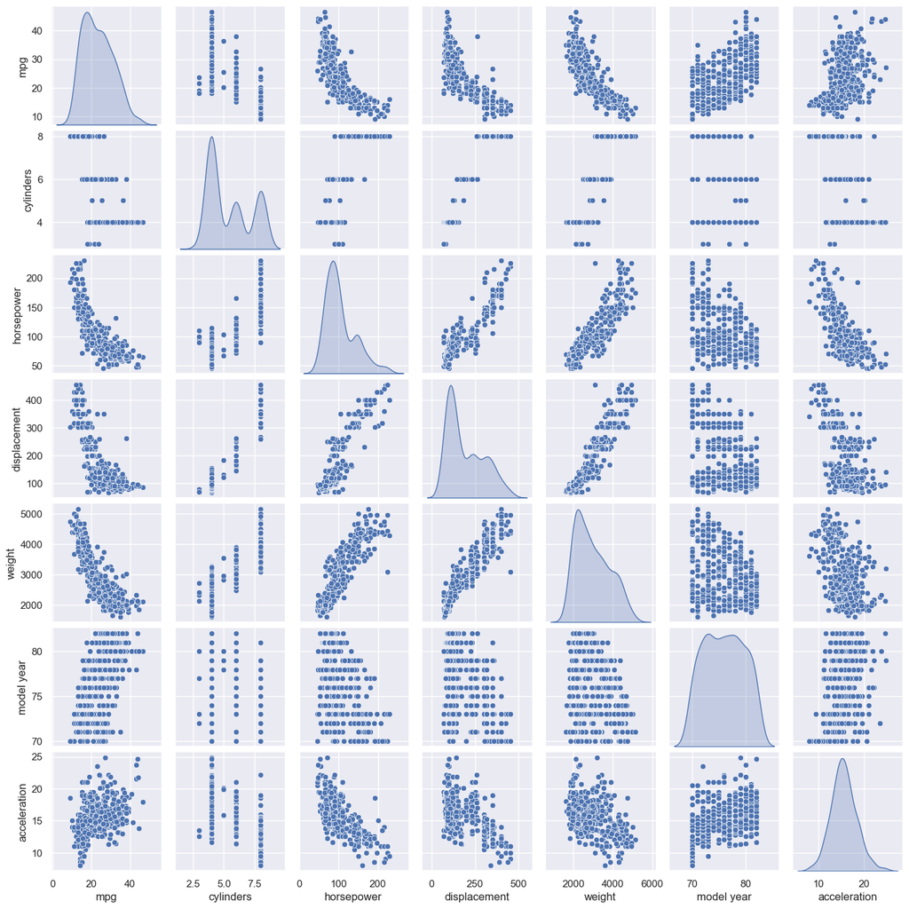

```python
sns.set()
columns = ['mpg','cylinders','horsepower','displacement','weight','model year','acceleration']
sns.pairplot(mpg[columns],size = 2 ,kind ='scatter',diag_kind='kde')
plt.show()
```

The previously identified correlations are all clearly illusrated here too.

### Scatter Plot

#### Scatter plots between the most correlated variables with MPG

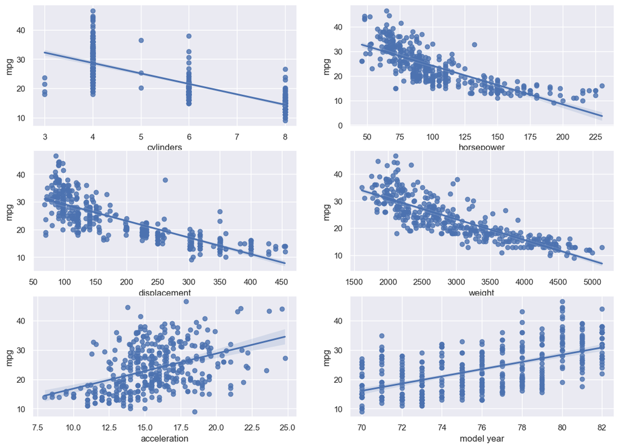

```python
fig, ((ax1, ax2), (ax3, ax4),(ax5,ax6)) = plt.subplots(nrows=3, ncols=2, figsize=(14,10))
cylinders_scatter_plot = pd.concat([mpg['mpg'],mpg['cylinders']],axis = 1)
sns.regplot(x='cylinders',y = 'mpg',data = cylinders_scatter_plot,scatter= True, fit_reg=True, ax=ax1)
horsepower_scatter_plot = pd.concat([mpg['mpg'],mpg['horsepower']],axis = 1)
sns.regplot(x='horsepower',y = 'mpg',data = horsepower_scatter_plot,scatter= True, fit_reg=True, ax=ax2)
displacement_scatter_plot = pd.concat([mpg['mpg'],mpg['displacement']],axis = 1)
sns.regplot(x='displacement',y = 'mpg',data = displacement_scatter_plot,scatter= True, fit_reg=True, ax=ax3)
weight_scatter_plot = pd.concat([mpg['mpg'],mpg['weight']],axis = 1)
sns.regplot(x='weight',y = 'mpg',data = weight_scatter_plot,scatter= True, fit_reg=True, ax=ax4)
acceleration_scatter_plot = pd.concat([mpg['mpg'],mpg['acceleration']],axis = 1)
sns.regplot(x='acceleration',y = 'mpg',data = acceleration_scatter_plot,scatter= True, fit_reg=True, ax=ax5)
model_year_scatter_plot = pd.concat([mpg['mpg'],mpg['model year']],axis = 1)
sns.regplot(x='model year',y = 'mpg',data = model_year_scatter_plot,scatter= True, fit_reg=True, ax=ax6)
```

Again, we can clearly see the negative correlations between MPG and cylinders, horsepower, displacement and weight, which would be intuitive.

Model year is also positively correlated with MPG, suggesting that newer cars are more fuel efficient.

Now plot a bar chart of median MPG by model year to examine the last correlation in more detail.

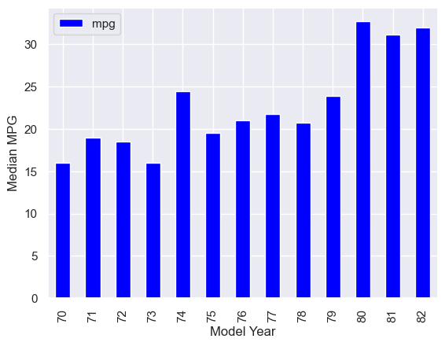

```python
mpg_model_year = mpg.pivot_table(index ='model year',values = 'mpg', aggfunc = np.median)
mpg_model_year.plot(kind = 'bar',color = 'blue')
plt.xlabel('Model Year')
plt.ylabel('Median MPG')
plt.show()
```

Box plot model year and cylinders

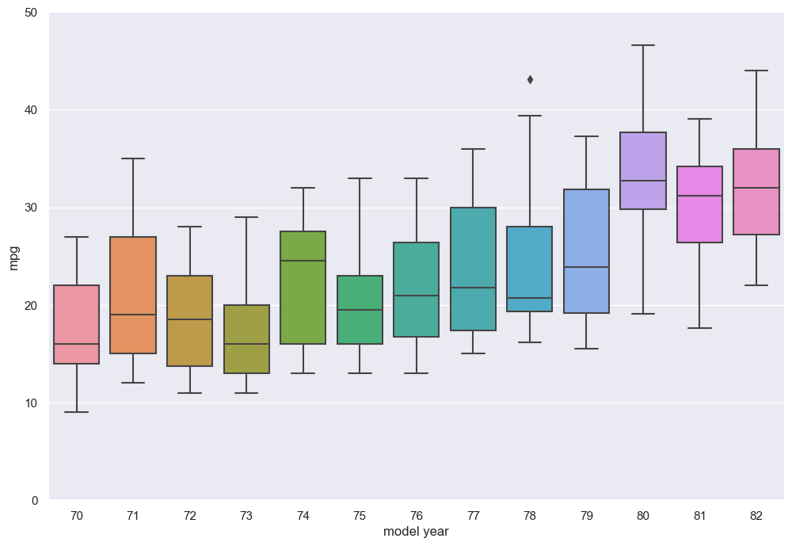

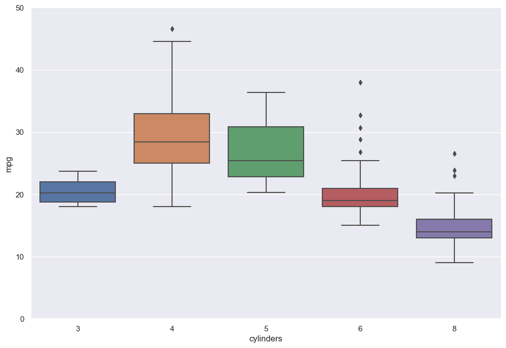

```python
var = 'model year'
data = pd.concat([mpg['mpg'], mpg[var]], axis=1)
f, ax = plt.subplots(figsize=(12, 8))
fig = sns.boxplot(x=var, y="mpg", data=data)
fig.axis(ymin=0, ymax=50);

var = 'cylinders'
data = pd.concat([mpg['mpg'], mpg[var]], axis=1)
f, ax = plt.subplots(figsize=(12, 8))
fig = sns.boxplot(x=var, y="mpg", data=data)
fig.axis(ymin=0, ymax=50);
```

Box Plot - origin

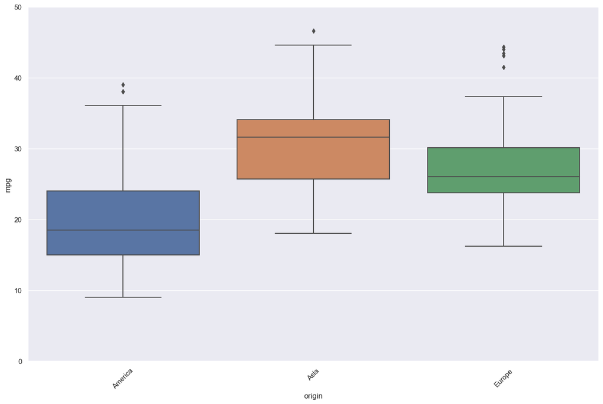

```python
var = 'origin'
data = pd.concat([mpg['mpg'], mpg[var]], axis=1)
f, ax = plt.subplots(figsize=(16, 10))
fig = sns.boxplot(x=var, y="mpg", data=data)
fig.axis(ymin=0, ymax=50);
xt = plt.xticks(rotation=45)
```

Cars from America have the lowest MPG, followed by Europe, and then finally cars from Asia have the highest MPG.